# Question #4

## Question #4: gradient boosting

We are using the `xgboost` package to answer this question. The `xgboost` package is incredibly powerful and flexible. You can learn more about it and the underlying algorithms here:

- [Rachael Tatman’s tutorial on Kaggle](https://www.kaggle.com/rtatman/machine-learning-with-xgboost-in-r)
- [`xgboost` page on readthedocs.io](https://xgboost.readthedocs.io/en/latest/index.html)

We followed the general steps in the tutorial to answer this question as it is our first time using the `xgboost` package.

1. Prepare the data
2. Run a sample model
3. Tune parameters to select a model with high accuracy and low chance of over-fitting

### Prepare the data

`xgboost` requires data to be in a particular format. The following code shows how to start with the output from the data prep section above and obtain the desired format for the algorithm.

```r
# Load Rds files from data prep section
loans_train     <- readr::read_rds('data/loans_train.Rds')
loans_test      <- readr::read_rds('data/loans_test.Rds')
loans_dv_train  <- readr::read_rds('data/loans_dv_train.Rds')
loans_dv_test   <- readr::read_rds('data/loans_dv_test.Rds')

# xgboost wants predictors and response in separate objects
train_labels <- loans_dv_train$Loan_Status.Y
test_labels <- loans_dv_test$Loan_Status.Y

# We will use this to tell the function to balance the Y/N values
negative_cases <- sum(train_labels == 0)
postive_cases <- sum(train_labels == 1)

# TODO why do we need this?
loans_dv <- rbind(loans_dv_test, loans_dv_train)
mloans <- as.matrix(loans_dv)

# xgboost can use a special xgb.DMatrix object
dtrain <- loans_dv_train %>%
  select(-Loan_Status.N, -Loan_Status.Y) %>%
  as.matrix %>%
  xgb.DMatrix(
    data = .,
    label = loans_dv_train$Loan_Status.Y %>% as.matrix)

# create the same for test data for the predict function
dtest <- loans_dv_test %>%
  select(-Loan_Status.N, -Loan_Status.Y) %>%
  as.matrix %>%
  xgb.DMatrix(
    data = .,
    label = loans_dv_test$Loan_Status.Y %>% as.matrix)
```

### Create a single pre-tuning model

It is always good when using a new method to start with a simple model to make sure everything is working properly.

The following function call includes the smallest number of non-default parameters. (In reality, `scale_pos_weight` is not required, but our labels are slightly imbalanced, so we include it as *mandatory*.)

```r
xgb1 <- xgboost(
  data = dtrain,
  objective = 'binary:logistic',
  eval_metric = 'error',
  scale_pos_weight = negative_cases/postive_cases,
  nrounds = 10)
```

```r
# Some helper functions
test_error <- function(model, n) {
  pred <- predict(model, newdata = dtest, ntreelimit = n)
  mean(as.numeric(pred > 0.5) != test_labels)
}

test_errors <- function(model) {
  N <- model$niter
  errors <- numeric(N)
  for (i in 1:N) {
    errors[i] <- test_error(model, i)
  }
  return(errors)
}

compare_errors <- function(model) {
  df <- cbind(
    model$evaluation_log %>% as.data.frame(),
    test_errors(model))
  names(df) <- c('iter', 'train_error', 'test_error')
  return(df)
}

# xgb1 errors
# TODO add kable formatting
compare_errors(xgb1)
```

```
##    iter train_error test_error
## 1     1    0.184382  0.2091503
## 2     2    0.154013  0.2026144
## 3     3    0.134490  0.2287582
## 4     4    0.121475  0.2156863
## 5     5    0.117137  0.2222222
## 6     6    0.121475  0.2222222
## 7     7    0.114967  0.2287582
## 8     8    0.106291  0.2222222
## 9     9    0.106291  0.2287582
## 10   10    0.106291  0.2222222
```

Even at iteration #1 we have evidence of over-fitting. And the test error increases on average as we add more trees. This is most likely because the defaults of `xgboost` allow for a max tree depth of six! Our selected decision model only had a depth of two, so we probably have over-fitting after just one iteration.

### Parameter tuning

There are dozens of parameters one can pass to the `xgboost` function, and we will not attempt to address them all here. The most important for our first foray into `xgboost` are probably the following

- `eta` the scaling factor applied to each iteration, default is 0.3
- `max_depth` controls the maximum size of each tree, default is 6
- `nround` is the number of iterations to run
- `early_stopping_rounds` controls whether to stop before reaching `nrounds`
- `gamma` is described best by the help page: “minimum loss reduction required to make a further partition on a leaf node of the tree. the larger, the more conservative the algorithm will be.”

Through experimentation not included in this write-up, we found that the small size of our data set means we do not need many boosting rounds to hit a plateau in the training accuracy. Therefore, `gamma` is probably not something we need to worry about. (`gamma` will help prevent too many iterations that have little overall impact.) The same argument applies to `early_stopping_rounds`.

The two arguments that make the most sense for us to tune are

- `max_depth` and
- `nround`

### Grid search

We run a grid search for the best combination of `max_depth` and `nround` by letting `max_depth` range from 1 to 5 (we already know 6 is not good) and `nround` range from 1 to 20. In practice, we set `nround` to 20 and only run the algorithm 5 times: once we have a 20-iteration result, we can use a subset of those iterations to accomplish the search.

```r
error_comps <- NULL

for (d in 1:5) {

  # verbose = 0 suppresses interactive output
  mod_d <- xgboost(
    data = dtrain,
    objective = 'binary:logistic',
    eval_metric = 'error',
    scale_pos_weight = negative_cases/postive_cases,
    nrounds = 20,
    max_depth = d,
    verbose = 0)

  error_comps_d <- compare_errors(mod_d)
  error_comps_d$max_depth <- d

  if (is.null(error_comps)) {
    error_comps <- error_comps_d
  } else {
    error_comps <- rbind(error_comps, error_comps_d)
  }
}
```

For each value of `max_depth` the best test errors are shown here:

```r
# TODO kable-fy
error_comps %>%
  group_by(max_depth) %>%
  summarize(min_test_error = min(test_error))
```

```
## # A tibble: 5 x 2
##   max_depth min_test_error
##       <int>          <dbl>
## 1         1          0.196
## 2         2          0.163
## 3         3          0.144
## 4         4          0.190
## 5         5          0.183
```

At `max_depth` of three, here are the results:

```r
error_comps %>%
  filter(max_depth == 3) %>%
  select(-max_depth) %>%
  mutate(
    train_error_counts = round(train_error * nrow(dtrain), 0),
    test_error_counts = round(test_error * nrow(dtest), 0))
```

```
##    iter train_error test_error train_error_counts test_error_counts
## 1     1    0.169197  0.1960784                 78                30
## 2     2    0.167028  0.1960784                 77                30
## 3     3    0.156182  0.1960784                 72                30
## 4     4    0.156182  0.1960784                 72                30
## 5     5    0.158351  0.1960784                 73                30
## 6     6    0.158351  0.2026144                 73                31
## 7     7    0.158351  0.2026144                 73                31
## 8     8    0.156182  0.1960784                 72                30
## 9     9    0.156182  0.2026144                 72                31
## 10   10    0.151844  0.2026144                 70                31
## 11   11    0.154013  0.2026144                 71                31
## 12   12    0.147505  0.1830065                 68                28
## 13   13    0.147505  0.1764706                 68                27
## 14   14    0.151844  0.1764706                 70                27
## 15   15    0.145336  0.1633987                 67                25
## 16   16    0.134490  0.1633987                 62                25
## 17   17    0.138829  0.1437908                 64                22
## 18   18    0.132321  0.1699346                 61                26
## 19   19    0.134490  0.1568627                 62                24
## 20   20    0.132321  0.1699346                 61                26
```

It is natural for our errors to move in a choppy way with such a small data set in a classification problem. With a larger data set we would see smoother patterns and a more convincing *minimum* point for our test errors. What we do see with our model is that at iteration 17 we finally get three more observations classified correctly and a low point for our test error.

### Selected parameters

The final model we selected is

```r
xgb_final <- xgboost(
  data = dtrain,
  objective = 'binary:logistic',
  eval_metric = 'error',
  scale_pos_weight = negative_cases/postive_cases,
  nrounds = 17,
  max_depth = 3,
  verbose = 0)
```

Seventeen may seem lot a lot of iterations, but remember each successive tree’s contribution to the whole is only 30% of its predecessor’s. The first tree carries the most weight by far. In fact, the last sixteen trees together have a weight less than half that of the first tree. It might be helpful to add up all the weights to get a comparative number of “fully-weighted” trees:

```r
.3^(0:16) %>% sum
```

```
## [1] 1.428571
```

### Interpretation

Boosted trees are not as easy to interpret as single trees, but there are still some things that are helpful. Like a variable importance plot:

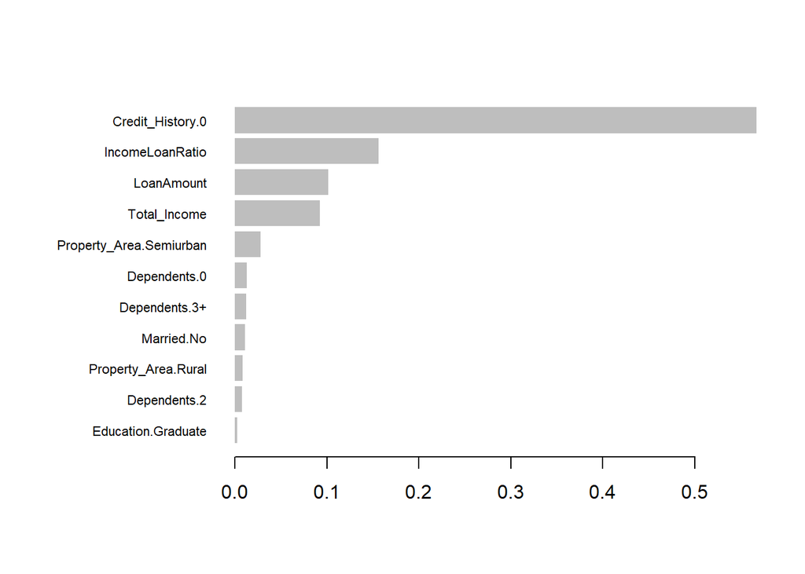

```r
importance_matrix <- xgb.importance(model = xgb_final)
xgb.plot.importance(importance_matrix)
```

The rank of importance agrees with our single-tree analysis, as we’d expect.